# Clinical Labs & Metadata

**File:** `sound_life_labs_metadata.csv` **Format:** Flat CSV, one row per sample visit **Join key:** `sample.sampleKitGuid` (shared across all modalities)

Subject metadata columns:

- `subject.subjectGuid` — unique subject ID
- `subject.biologicalSex` — biological sex
- `subject.birthYear` — birth year
- `subject.ageAtFirstDraw` — age at first visit
- `subject.race`, `subject.ethnicity`

Sample metadata columns:

- `sample.sampleKitGuid` — unique visit/sample ID (cross-modality join key)
- `sample.visitName` — visit label (e.g. "Flu Year 1 Day 0")
- `sample.visitDetails` — additional visit context
- `sample.drawYear` — year of sample collection
- `sample.subjectAgeAtDraw` — age at this visit
- `sample.daysSinceFirstVisit` — days elapsed since first visit
- `sample.diseaseStatesRecordedAtVisit` — any disease states at visit

Clinical variable groups (prefix indicates group):

**Anthropometric (prefix: am)**

- `am.bmi`, `am.height` (cm), `am.weight` (kg)

**Blood Chemistry (prefix: chem)** — 20 variables

- Liver: `chem.alt`, `chem.ast`, `chem.alkaline_phosphatase`, `chem.albumin`, `chem.globin`, `chem.t_bili`
- Kidney: `chem.creatinine`, `chem.bun`, `chem.egfr_aa`, `chem.egfr_non_aa`
- Electrolytes: `chem.sodium`, `chem.potassium`, `chem.cl`, `chem.co2`, `chem.calcium`, `chem.magnesium`, `chem.phosphate`
- Metabolic: `chem.glucose`, `chem.ldh`, `chem.protein`

**Blood Counts (prefix: bc)** — 20 variables

- Differentials: `bc.perc_basophils`, `bc.perc_eosinophils`, `bc.perc_lymphocytes`, `bc.perc_monocytes`, `bc.perc_neutrophils`
- Absolute counts: `bc.basophil_count`, `bc.eosinophil_count`, `bc.lymphocyte_count`, `bc.monocyte_count`, `bc.neutrophil_count`
- RBC panel: `bc.hematocrit`, `bc.hemoglobin`, `bc.mch`, `bc.mchc`, `bc.mcv`, `bc.red_blood_cell_count`, `bc.rdw`
- Other: `bc.mpv`, `bc.platelet_count`, `bc.wbc`

**HCMV Serology (prefix: cmv)**

- `cmv.igg_serology` — CMV IgG ELISA result
- `cmv.igg_serology_interpretation` — Positive / Negative / Equivocal

**Inflammatory Markers (prefix: infl)**

- `infl.hs_crp` — high-sensitivity CRP (key immune activation marker)
- `infl.esr` — SED rate (Westergren)
- `infl.anti_ccp3`, `infl.anti_ccp31` — anti-CCP antibodies
- `infl.rf_iga_result`, `infl.rf_iga_interpretation`
- `infl.rf_igm_result`, `infl.rf_igm_interpretation`

**Lipid Profile (prefix: lip)**

- `lip.cholesterol_hdl`, `lip.cholesterol_ldl`, `lip.cholesterol_non_hdl`, `lip.cholesterol_total`, `lip.chlesterol_hdl_ratio`, `lip.triglycerides

|  | cohort.cohortGuid | subject.subjectGuid | sample.sampleKitGuid | subject.biologicalSex | subject.birthYear | subject.ageAtFirstDraw | subject.ageGroup | subject.race | subject.ethnicity | sample.visitName | ... | infl.rf_iga_result | infl.rf_igm_interpretation | infl.rf_igm_result | infl.esr | lip.cholesterol_hdl | lip.cholesterol_ldl | lip.cholesterol_non_hdl | lip.cholesterol_total | lip.chlesterol_hdl_ratio | lip.triglycerides |
| --- | --- | --- | --- | --- | --- | --- | --- | --- | --- | --- | --- | --- | --- | --- | --- | --- | --- | --- | --- | --- | --- |
| 0 | BR1 | BR1001 | KT00001 | Female | 1987 | 32 | Young Adult | Caucasian | Non-Hispanic origin | Flu Year 1 Day 0 | ... | 0.0 | Negative | 5.902 | 2.0 | 65.0 | 85.0 | 104.0 | 169.0 | 2.6 | 94.0 |
| 1 | BR1 | BR1002 | KT00002 | Male | 1991 | 28 | Young Adult | Caucasian | Non-Hispanic origin | Flu Year 1 Day 0 | ... | NaN | NaN | NaN | 2.0 | 56.0 | 72.0 | 99.0 | 155.0 | 2.8 | 197.0 |
| 2 | BR1 | BR1003 | KT00003 | Female | 1989 | 30 | Young Adult | Caucasian | Non-Hispanic origin | Flu Year 1 Day 0 | ... | NaN | NaN | NaN | 2.0 | 76.0 | 112.0 | 126.0 | 202.0 | 2.7 | 57.0 |
| 3 | BR1 | BR1004 | KT00004 | Male | 1989 | 30 | Young Adult | Caucasian | Non-Hispanic origin | Flu Year 1 Day 0 | ... | NaN | NaN | NaN | 2.0 | 60.0 | 63.0 | 76.0 | 136.0 | 2.3 | 47.0 |
| 4 | BR1 | BR1005 | KT00006 | Female | 1992 | 27 | Young Adult | Caucasian | Non-Hispanic origin | Flu Year 1 Day 0 | ... | NaN | NaN | NaN | 2.0 | 50.0 | 79.0 | 102.0 | 152.0 | 3.0 | 130.0 |

5 rows × 74 columns

|  | subject.birthYear | subject.ageAtFirstDraw | sample.drawYear | sample.subjectAgeAtDraw | sample.daysSinceFirstVisit | sample.diseaseStatesRecordedAtVisit | am.bmi | am.height | am.weight | chem.alt | ... | infl.hs_crp | infl.rf_iga_result | infl.rf_igm_result | infl.esr | lip.cholesterol_hdl | lip.cholesterol_ldl | lip.cholesterol_non_hdl | lip.cholesterol_total | lip.chlesterol_hdl_ratio | lip.triglycerides |
| --- | --- | --- | --- | --- | --- | --- | --- | --- | --- | --- | --- | --- | --- | --- | --- | --- | --- | --- | --- | --- | --- |
| count | 868.000000 | 868.000000 | 868.000000 | 868.000000 | 868.000000 | 0.0 | 683.000000 | 683.000000 | 831.000000 | 858.000000 | ... | 852.000000 | 97.000000 | 97.000000 | 856.000000 | 858.000000 | 844.000000 | 858.000000 | 858.000000 | 858.000000 | 858.000000 |
| mean | 1974.594470 | 45.258065 | 2020.682028 | 46.087558 | 277.458525 | NaN | 26.424597 | 169.678507 | 75.793699 | 19.764569 | ... | 1.410681 | 0.263103 | 2.735526 | 5.141355 | 62.090909 | 110.708531 | 133.547786 | 195.638695 | 3.324825 | 124.847319 |
| std | 14.392875 | 14.501807 | 0.712582 | 14.522756 | 209.352816 | NaN | 4.804517 | 8.721788 | 15.652305 | 11.249709 | ... | 1.803708 | 1.413195 | 8.264399 | 5.854562 | 17.078408 | 31.953449 | 36.932474 | 41.475218 | 0.986502 | 86.022581 |
| min | 1955.000000 | 25.000000 | 2019.000000 | 25.000000 | 0.000000 | NaN | 0.000000 | 147.000000 | 0.000000 | 6.000000 | ... | 0.300000 | 0.000000 | 0.000000 | 2.000000 | 25.000000 | 13.000000 | 27.000000 | 77.000000 | 1.500000 | 27.000000 |
| 25% | 1961.000000 | 31.000000 | 2020.000000 | 31.000000 | 89.750000 | NaN | 23.000000 | 162.600000 | 64.450000 | 13.000000 | ... | 0.400000 | 0.000000 | 0.000000 | 2.000000 | 51.000000 | 88.000000 | 107.000000 | 169.250000 | 2.700000 | 70.000000 |
| 50% | 1965.000000 | 55.000000 | 2021.000000 | 55.000000 | 262.000000 | NaN | 26.000000 | 169.900000 | 74.500000 | 17.000000 | ... | 0.700000 | 0.000000 | 0.000000 | 2.000000 | 60.000000 | 108.000000 | 131.000000 | 191.000000 | 3.100000 | 98.000000 |
| 75% | 1989.000000 | 59.000000 | 2021.000000 | 60.000000 | 438.500000 | NaN | 29.000000 | 175.550000 | 85.600000 | 23.000000 | ... | 1.600000 | 0.000000 | 1.896000 | 6.000000 | 73.000000 | 131.000000 | 157.000000 | 221.000000 | 3.700000 | 151.750000 |
| max | 1995.000000 | 65.000000 | 2022.000000 | 67.000000 | 856.000000 | NaN | 45.000000 | 190.500000 | 117.700000 | 113.000000 | ... | 10.000000 | 12.027000 | 73.066000 | 46.000000 | 131.000000 | 212.000000 | 251.000000 | 313.000000 | 7.000000 | 677.000000 |

8 rows × 62 columns

```
Unique subjects: 96
Unique samples: 868
sample.sampleKitGuid
10    78
2      4
3      3
9      3
6      3
8      2
5      1
4      1
1      1
Name: count, dtype: int64
```

```
subject.biologicalSex
Female    55
Male      41
Name: count, dtype: int64
subject.ageGroup
Young Adult    49
Older Adult    47
Name: count, dtype: int64
subject.race
Caucasian           83
Asian                8
Other                4
African American     1
Name: count, dtype: int64
subject.ethnicity
Non-Hispanic origin          93
Hispanic or Latino origin     3
Name: count, dtype: int64
cmv.igg_serology_interpretation
Negative    48
Positive    44
Name: count, dtype: int64
```

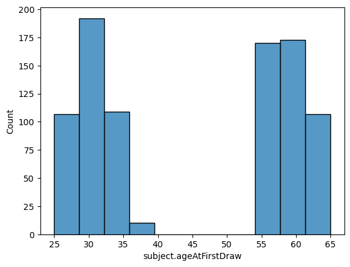

## Missing Data

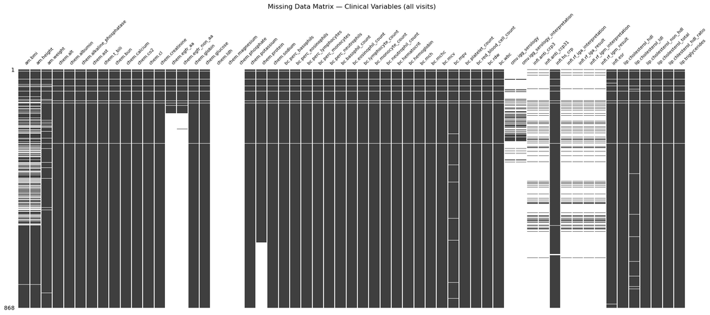

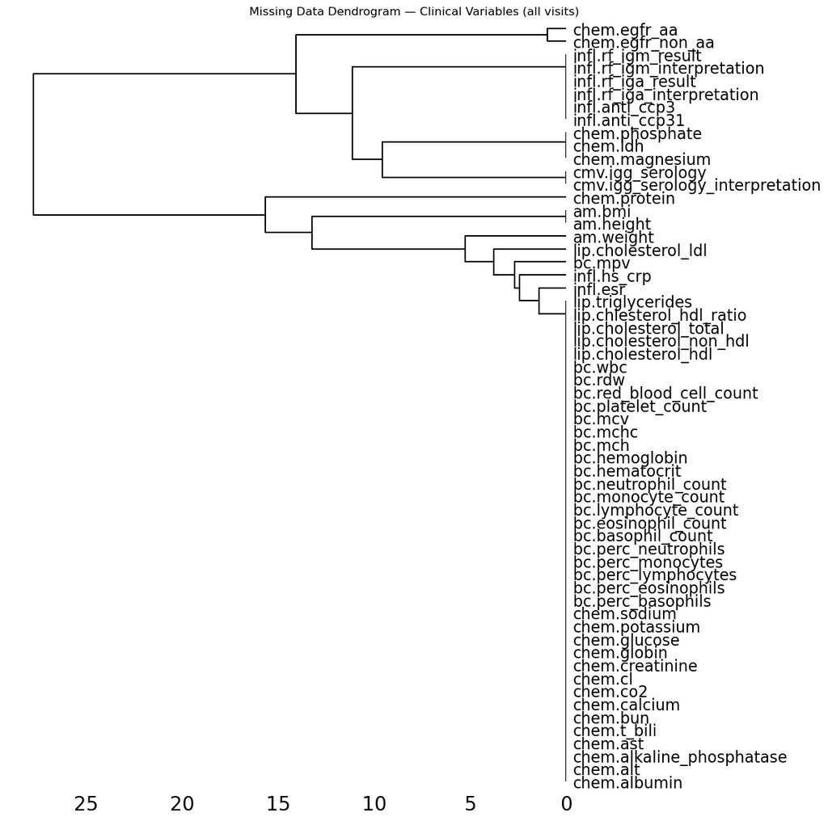

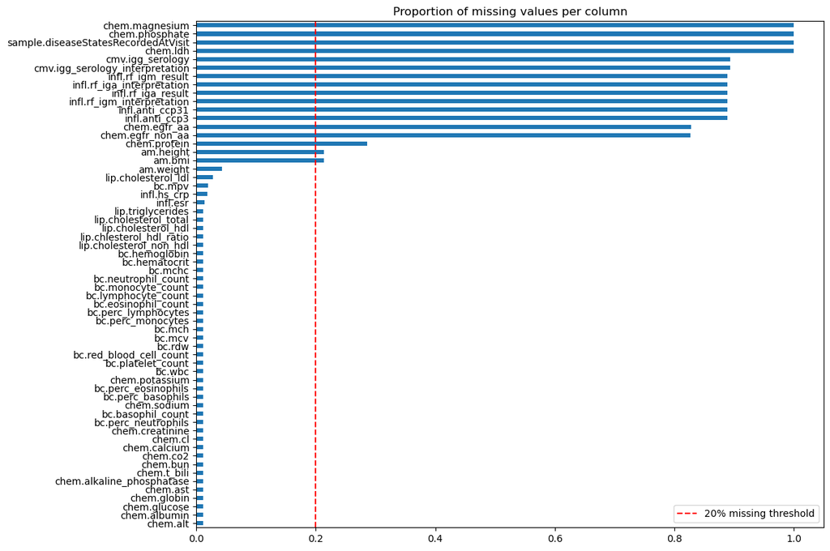

## Clinical Variable Distributions

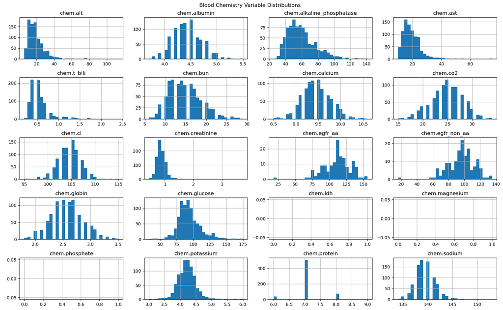

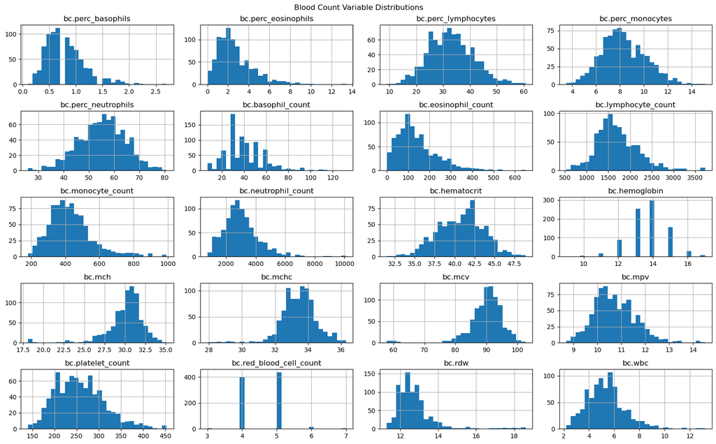

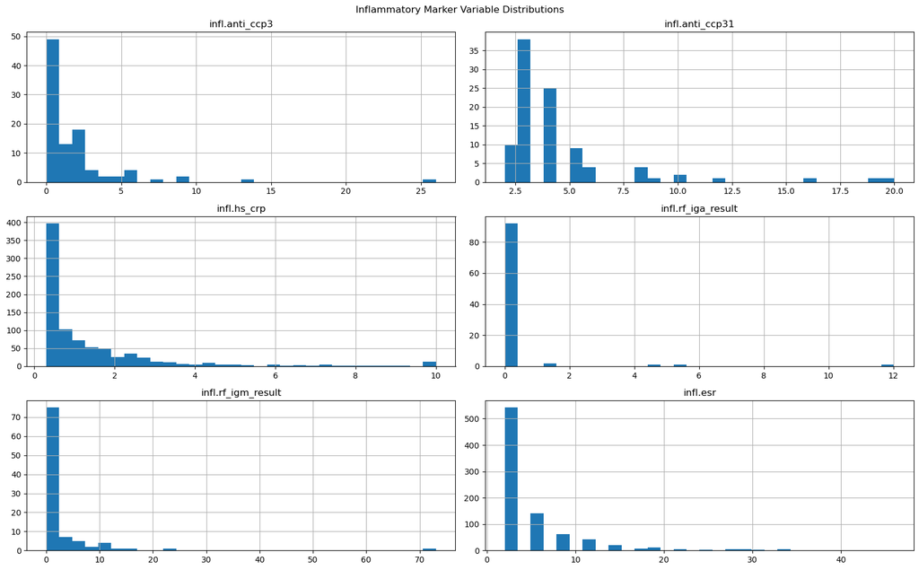

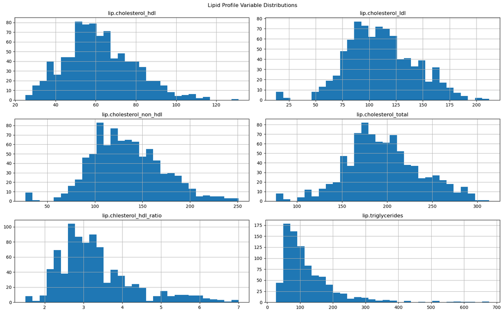

## Age Group Comparisons

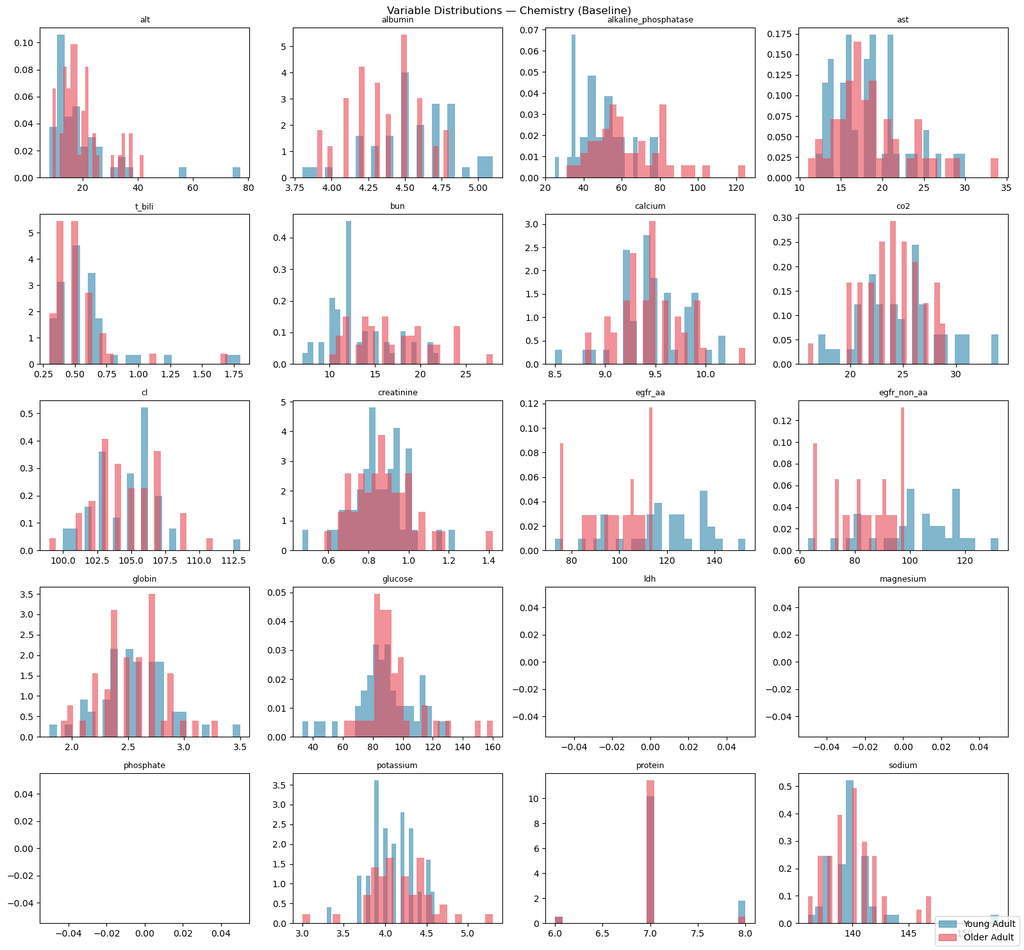

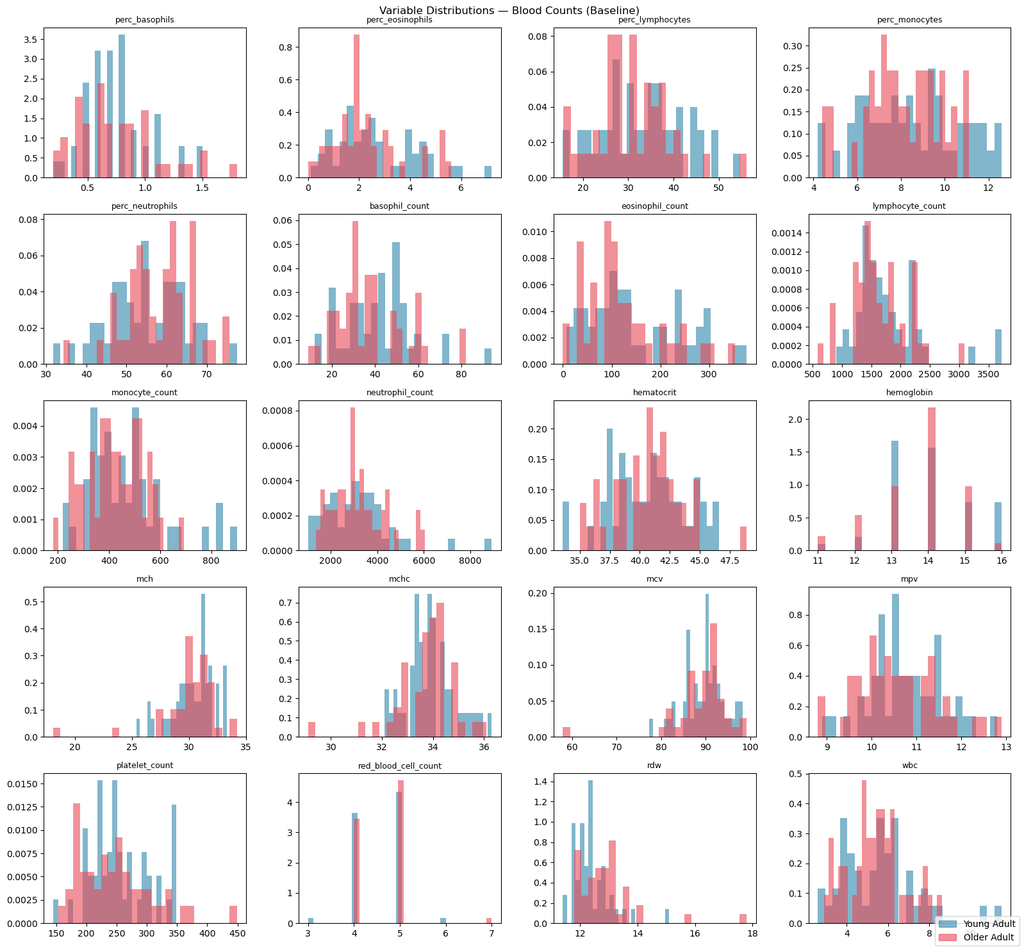

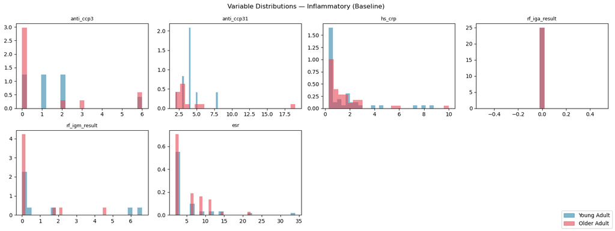

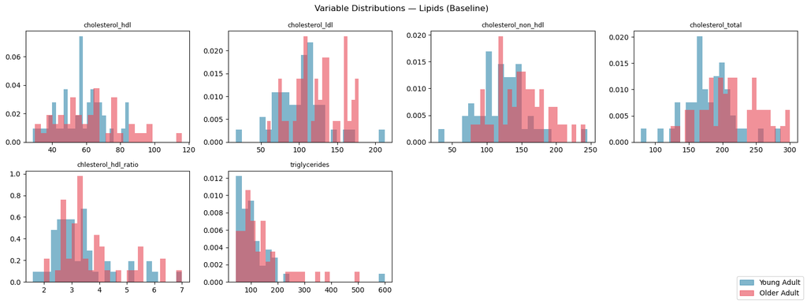

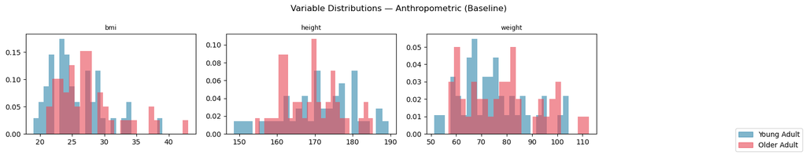

- `infl.hs_crp` and `infl.esr` are both markers of systemic low-grade inflammation. Chronic inflammation that accumulates with age (inflammaging) is one of the most replicated findings in immunogerontology. CRP tends to be more sensitive to accute changes, while ESR integrates over a longer window, so having both tests whether the signal is consistent.
- `bc.lymphocyte_count` directly captures immunosenescence (i.e., gradual deteriotation of the immune system that occurs naturally with age) -- one of the clearest cellular signatures of immune aging in the Gong et al. paper. Lymphocyte counts decline with age as the naive T cell compartment shrinks and is replaced by terminally differentiated effector memory cells.
- `bc.neutrophil_count` / `bc.lymphocyte_count` ratio (NLR) is an established inflammaging marker -- as lymphocytes decline and low-grade inflammation persists, neutrophil counts tend to rise relative to lymphocytes, and `bc.wbc` captures the overall picture
- `am.bmi` is a proxy for metabolic health and adiposity, both of which are correlated with inflammatory tone and change across the lifespan
- `lip.cholesterol_ldl` and `lip.triglycerides` reflect cardiometabolic health, which deteriorates with age and is bidirectionally linked to immune function -- lipid dysregulation promotes vascular inflammation, and inflammation in turn affects lipid metabolism

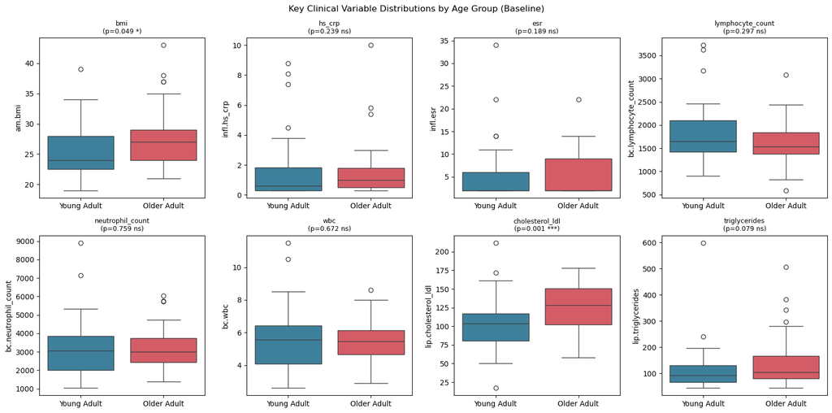

## CMV Status

**CMV**: cytomegalovirus (Human Cytomegalovirus, HCMV) -- a betaherpesvirus that infects roughly 50-80% of adults in developed countries, typically silently. CMV establishes lifelong latency after primary infection: the virus never leaves the body, and the immune system must continuously surveil and suppress periodic reactivations for the rest of the host's lkife.

The continuous immune serveillance of latent CMV drives several well-document changes:

- **T cell compartment remodeling**: The immune system mounts a large, sustained CMV-specific CD8+ T cell response. Over decades, these CMV-specific T cells — particularly a terminally differentiated effector memory subset called T-EMRA cells — accumulate and occupy an ever-larger fraction of the total T cell pool. This crowds out naive T cells, which are the cells responsible for responding to new pathogens and vaccines. CMV+ individuals therefore have fewer naive T cells and a more "experienced" but less flexible T cell repertoire.
- **Acclerated immune aging**: The T cell composition of a CMV+ person in their 40s can look immunologically similar to a CMV− person decades older. This is one of the reasons CMV serostatus is considered a major driver of what researchers call the immune risk profile — the constellation of immune changes associated with poor health outcomes in older adults.
- **Elevated inflammatory tone**: CMV+ individuals tend to have modestly higher levels of systemic inflammatory markers, including CRP and IL-6, likely because the immune system is under continuous low-level activation.
- **NK cell differentiation**: CMV also drives expansion of a specific NK cell subset (NKG2C+) that is rarely seen in CMV− individuals.

```
cmv.igg_serology_interpretation  Negative  Positive
subject.ageGroup
Older Adult                            22        25
Young Adult                            26        19
```

```
Chi2ContingencyResult(statistic=np.float64(0.7125402965828489), pvalue=np.float64(0.39860178273263147), dof=1, expected_freq=array([[24.52173913, 22.47826087],
       [23.47826087, 21.52173913]]))
```

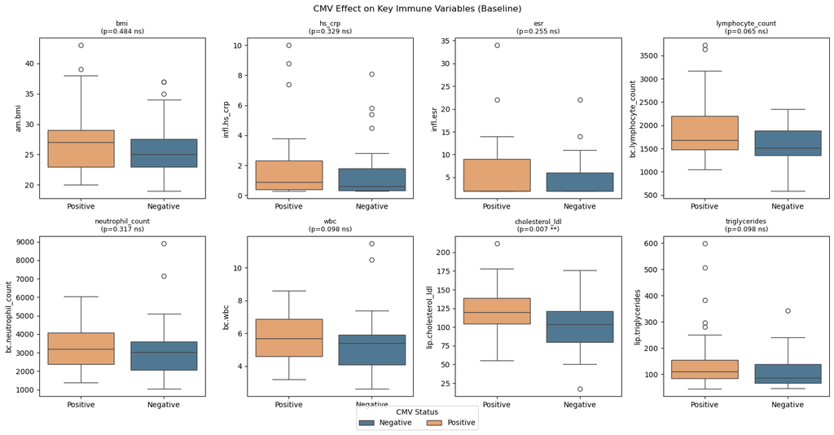

## Longitudinal Stability

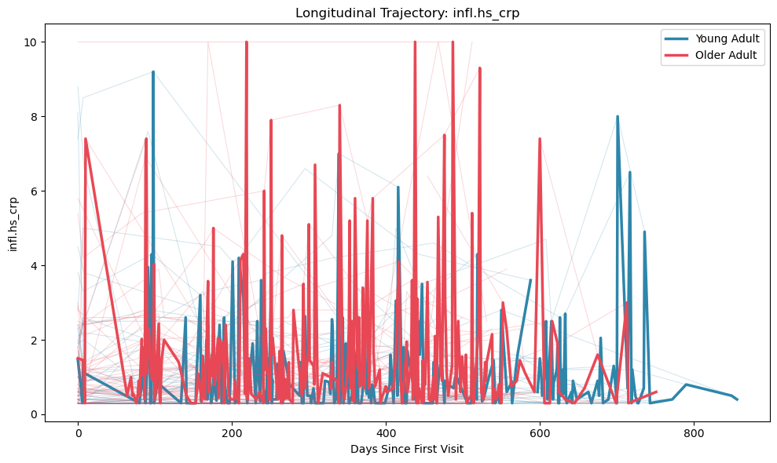

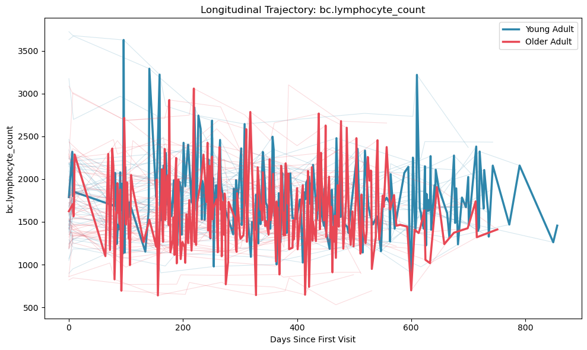

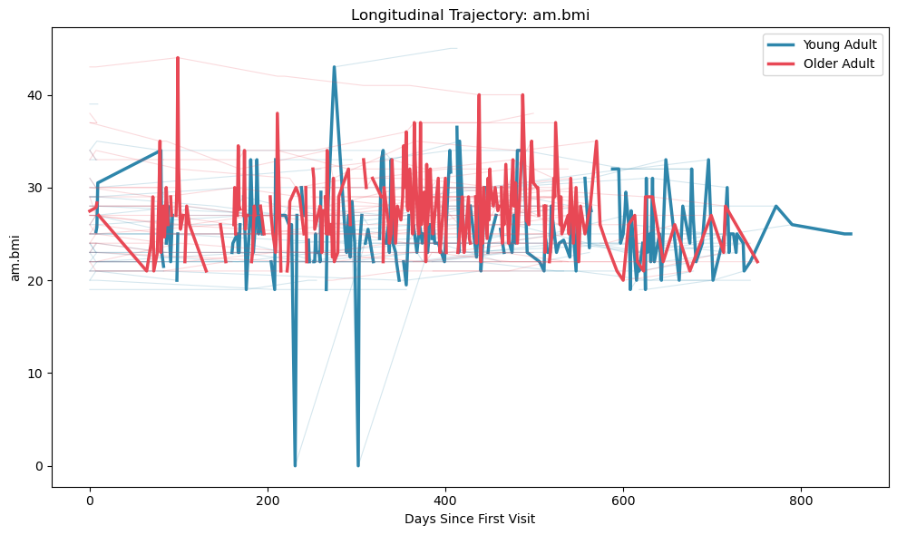

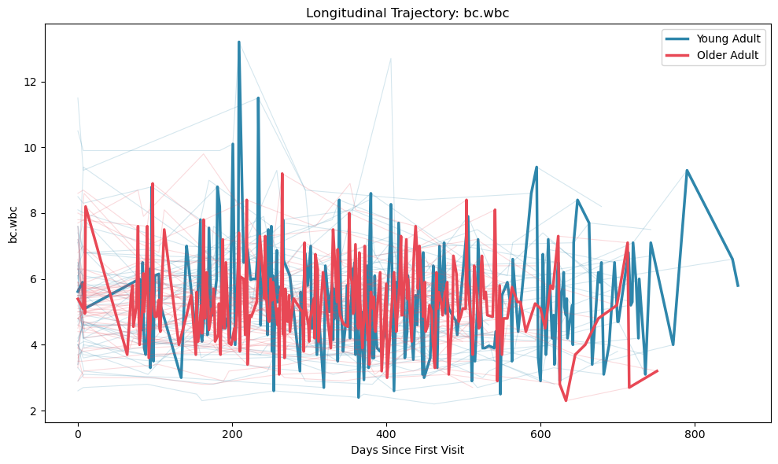

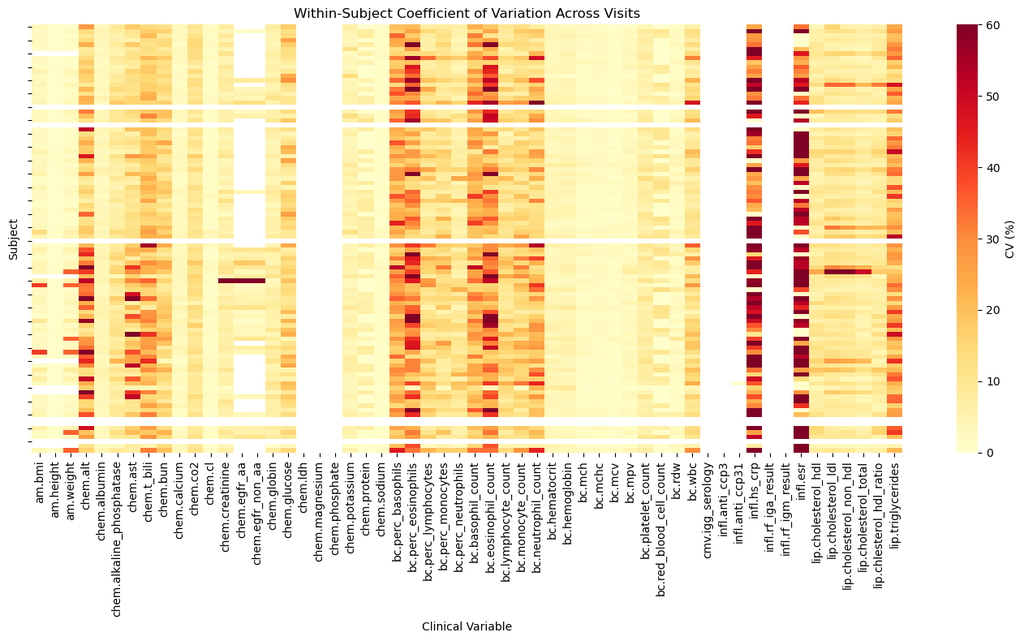

## Correlation Structure

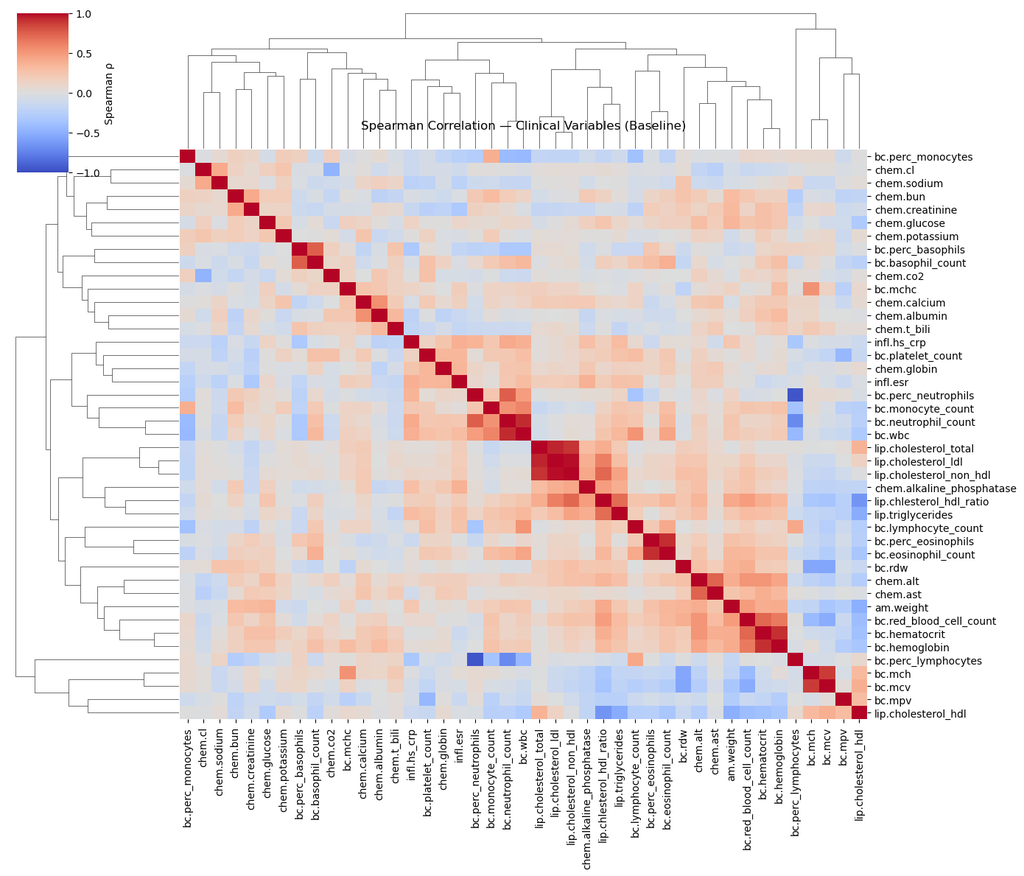